# Analisi COVID

# Abstract

L’obiettivo di questa analisi è stimare l’incremento di decessi nel primo triennio del 2020 nella regione Lombardia, rispetto alla media dei decessi negli stessi mesi tra il 2015 e il 2019. Tale cifra è stata stimata basandosi sui dati di 1120 comuni lombardi selezionati da ISTAT seguendo determinati **criteri**, specificati di seguito.

- Appartenenza all’ANPR;
- Incremento di decessi nel mese di marzo maggiore del 20% rispetto alla media dei 5 anni precedenti;
- Almeno 10 decessi nei primi tre mesi del 2020;
- Dati 2020 ritenuti affidabili dall’ISTAT.

Pertanto, i comuni risultano divisi in **tre sotto-gruppi**:

- *Comuni noANPR*: comuni non iscritti all’ANPR.
- *Comuni ignoti*: comuni iscritti all’ANPR ma che non soddisfano almeno uno degli altri criteri elencati precedentemente.
- *Comuni noti*: comuni iscritti all’ANPR e con dati relativi al 2020 disponibili.

Di seguito sono riportate le proporzioni delle tre tipologie di comuni e la relativa distribuzione geografica, ottenuta con il software Tableau:

[figure not shown]

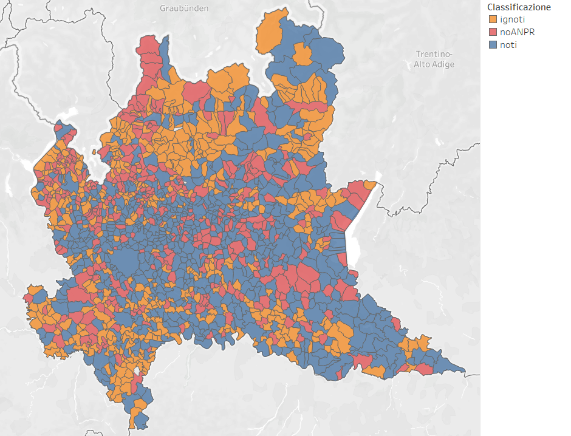

# Lettura e preparazione dei dataset

Per l’analisi sono stati utilizzati i seguenti dataset:

- comune_giorno.csv, contenente i decessi giorno per giorno nel primo trimestre degli anni 2015-2020;
- Popolazione_comuni_italiani.csv, contenente i dati sulla popolazione dei comuni italiano nel 2019;
- Comuni_ANPR.xlsx, lista dei comuni italiani iscritti all’ANPR;
- italy_geo.xlsx, relativo alla posizione geografica dei comuni italiani.

Inoltre, nella fase finale si è utilizzato il dataset ISTAT aggiornato del 5 maggio, contenente i dati dei decessi 2020 per il 97% dei comuni lombardi. Questo ha consentito di confrontare la stima ottenuta dall’analisi con i dati ufficiali.

Lettura dei dataset:

```r
library(readr)
library(readxl)
library(lubridate)
library(stringi)
library(geosphere)
library(tidyr)
library(dplyr)
library(microbenchmark)
library(ggplot2)

comune_giorno <- read_csv("dati-giornalieri-comune/comune_giorno.csv",
                          locale = locale(encoding = "ISO-8859-1"))

popolazione_comuni_italiani <- read_csv("Popolazione_comuni_italiani.csv")

comuni_ANPR <- read_excel("Comuni_ANPR.xlsx")

italy_geo <- suppressWarnings(read_excel("italy_geo.xlsx",
    sheet = "italy_geo", col_types = c("numeric",
        "text", "numeric", "numeric")))

dataset_aggiornato <- read_excel("Dati_aggiornati.xlsx",
    sheet = "Totale per periodo", col_types = c("text",
        "text", "text", "text", "text", "text",
        "skip", "skip", "skip", "numeric",
        "numeric", "numeric", "skip", "skip",
        "skip"), skip = 1)
```

Selezione Lombardia:

```r
Lombardia <- select(filter(comune_giorno, NOME_REGIONE == "Lombardia"),
                    c(1:27))
```

```r
italy_geo <- mutate(italy_geo, comune = stri_trans_tolower(comune))[c(2:4)]
Lombardia <- mutate(Lombardia, NOME_COMUNE = stri_trans_tolower(NOME_COMUNE))
```

In seguito al confronto dei vari dataset, si sono notate delle differenze nelle denominazioni di alcuni comuni, a causa di fusioni o modifiche dei singoli nomi nel corso degli anni. È stato quindi necessario aggiornare manualmente i comuni in questione, con la relativa posizione:

```r
# noANPR

# Cadrezzate con Osmate
Cadrezzate_con_Osmate <- data.frame(comune = "cadrezzate con osmate", lng = 8.6444, lat = 45.8002)
italy_geo <- rbind(italy_geo, Cadrezzate_con_Osmate)

# Solbiate con Cagno
Solbiate_con_Cagno <- data.frame(comune = "solbiate con cagno", lng = 8.9342, lat = 45.7906)
italy_geo <- rbind(italy_geo, Solbiate_con_Cagno)

# Vermezzo con Zelo
Vermezzo_con_Zelo <- data.frame(comune = "vermezzo con zelo", lng = 8.9801, lat = 45.3972)
italy_geo <- rbind(italy_geo, Vermezzo_con_Zelo)

# Puegnago del Garda
italy_geo[italy_geo == "puegnago sul garda"] <- "puegnago del garda"

# Colli Verdi
Colli_Verdi <- data.frame(comune = "colli verdi", lng = 9.2741, lat = 44.9290)
italy_geo <- rbind(italy_geo, Colli_Verdi)

# Valvarrone
Valvarrone <- data.frame(comune = "valvarrone", lng = 9.3259, lat = 46.0842)
italy_geo <- rbind(italy_geo, Valvarrone)



# noti

# San Giorgio Bigarello
italy_geo[italy_geo == "san giorgio di mantova"] <- "san giorgio bigarello"

# Borgo Mantovano
Borgo_Mantovano <- data.frame(comune = "borgo mantovano", lng = 11.1323, lat = 45.0544)
italy_geo <- rbind(italy_geo, Borgo_Mantovano)

# Borgocarbonara
Borgocarbonara <- data.frame(comune = "borgocarbonara", lng = 11.2338, lat = 45.0375)
italy_geo <- rbind(italy_geo, Borgocarbonara)

# Centro Valle Intelvi
Centro_Valle_Intelvi <- data.frame(comune = "centro valle intelvi", lng = 9.0818, lat = 45.9686)
italy_geo <- rbind(italy_geo, Centro_Valle_Intelvi)

# Piadena Drizzona
Piadena_Drizzona <- data.frame(comune = "piadena drizzona", lng = 10.3694, lat = 45.1275)
italy_geo <- rbind(italy_geo, Piadena_Drizzona)



# ignoti

# Castelgerundo
Castelgerundo <- data.frame(comune = "castelgerundo", lng = 9.7429, lat = 45.1907)
italy_geo <- rbind(italy_geo, Castelgerundo)

# Pedesina
Lombardia <- subset(Lombardia, NOME_COMUNE != 'pedesina')
comuni_ANPR <- subset(comuni_ANPR, Comune != 'PEDESINA')



# San Giorgio Bigarello
popolazione_comuni_italiani[popolazione_comuni_italiani == "San Giorgio di Mantova"] <- "San Giorgio Bigarello"



remove(Cadrezzate_con_Osmate, Solbiate_con_Cagno, Vermezzo_con_Zelo, Colli_Verdi, Valvarrone,
       Borgo_Mantovano, Borgocarbonara, Centro_Valle_Intelvi, Piadena_Drizzona, Castelgerundo)
```

Selezione dei comuni lombardi all’interno del dataset delle posizioni:

```r
italy_geo <- inner_join(italy_geo, Lombardia[,c(5)], by = c("comune" = "NOME_COMUNE"))
italy_geo %>% group_by(comune) %>% summarise(lng = first(lng), lat = first(lat)) -> italy_geo
```

Selezione dei primi 3 mesi dell’anno:

```r
Lombardia %>% separate(GE, into=c("MESE", "GIORNO"), sep=2, convert=T, remove=F) -> Lombardia
Lombardia <- select(filter(Lombardia, MESE <= 3), c(1:29))
```

# Stima dei comuni noti

Calcolo dell’incremento dei decessi nei comuni noti tramite la differenza tra i decessi nel 2020 e la media degli anni precedenti. Per il calcolo dell’incertezza di questa media si è deciso di utilizzare un intervallo di confidenza al 95%.

```r
comuni_noti <- select(filter(Lombardia, TOTALE_20 < 9999), c(1:29))
comuni_noti <- comuni_noti %>% gather(key = "SESSO_ANNO", value = "DECESSI", MASCHI_15:TOTALE_20)
comuni_noti %>% separate(SESSO_ANNO, c("SESSO", "ANNO"), "_") -> comuni_noti
comuni_noti <- select(filter(comuni_noti, SESSO != "TOTALE"), c(1:14))
comuni_noti %>% group_by(NOME_COMUNE, ANNO) %>% summarise(DECESSI = sum(DECESSI)) -> comuni_noti

comuni_noti2020 <- select(filter(comuni_noti, ANNO == "20"), c(1:3))
comuni_noti1519 <- setdiff(comuni_noti, comuni_noti2020)

comuni_noti1519 %>% group_by(NOME_COMUNE) %>% summarise(DECESSI_MEDI = mean(DECESSI), INCERTEZZA = 1.96 * sd(DECESSI) / sqrt(5-1)) -> comuni_noti1519
```

```r
eccesso_noti <- merge(comuni_noti1519, comuni_noti2020, by = 'NOME_COMUNE')[,c(1,2,3,5)]
colnames(eccesso_noti)[4] <- "DECESSI_20"
eccesso_noti <- mutate(eccesso_noti, INCREMENTO = DECESSI_20 - DECESSI_MEDI)
```

# Stima dei comuni non iscritti all’ANPR

Preparazione dataframe ANPR:

```r
# Selezione dei comuni lombardi iscritti ad ANPR prima del 1/1/2020

comuni_ANPR %>% mutate(data = as.Date(comuni_ANPR$'Data subentro', format="%d/%m/%Y")) -> comuni_ANPR

comuni_ANPR <- select(filter(comuni_ANPR, data < "2020-01-01"), c(1,5))
comuni_ANPR <- select(filter(comuni_ANPR, Regione == "LOMBARDIA"), c(1,2))


comuni_ANPR <- mutate(comuni_ANPR, Comune = stri_trans_tolower(Comune))
```

Creazione del dataset *comuni_noANPR* tramite la differenza tra l’elenco dei comuni della Lombardia e quelli iscritti all’ANPR.

```r
comuni_noANPR <- as.data.frame(setdiff(Lombardia$NOME_COMUNE, comuni_ANPR$Comune))
names(comuni_noANPR) <- c("NOME_COMUNE")
comuni_noANPR %>% group_by(NOME_COMUNE) %>% summarise() -> comuni_noANPR
```

È stato poi aggiunto al dataframe precedentemente creato il dato relativo alla popolazione di ogni comune, per poter calcolare l’incremento relativo di decessi sulla popolazione rispetto agli anni precedenti, con la relativa incertezza:

```r
popolazione_comuni_italiani <- mutate(popolazione_comuni_italiani,
                                      Territorio = stri_trans_tolower(Territorio))
popolazione_comuni_italiani <- select(filter(popolazione_comuni_italiani, Sesso == "totale"), c(2,13))

popolazione_comuni_italiani %>% group_by(Territorio) %>% summarise(Value = mean(Value)) -> popolazione_comuni_italiani

eccesso_noti <- inner_join(eccesso_noti, popolazione_comuni_italiani, by = c("NOME_COMUNE" = "Territorio"))

eccesso_noti["INCR_RELATIVO"] <- eccesso_noti["INCREMENTO"] / eccesso_noti["Value"]
eccesso_noti['INCERTEZZA_REL'] <- eccesso_noti["INCERTEZZA"] / eccesso_noti["Value"]
```

Si è deciso di stimare innanzitutto l’incremento di decessi nel 2020 per i comuni non appartenenti all’ANPR. Per fare ciò, si è ritenuto ragionevole ipotizzare che l’impatto dell’epidemia nei vari comuni dipenda principalmente dai comuni vicini. Pertanto, si è supposto che l’incremento percentuale dei decessi nei comuni limitrofi fosse simile rispetto a quello del comune ignoto. In particolare, per selezionare i comuni vicini, si è stabilito un raggio di 10km.

È stata quindi calcolata una matrice delle distanze tra i comuni utilizzando la distanza di Haversine, in base alla latitudine e alla longitudine dei comuni stessi.

Infine, dopo aver selezionato per ogni comune i relativi vicini, la stima dei decessi nel comune noANPR è stata calcolata come media degli incrementi percentuali dei vicini (e analogamente per la relativa incertezza).

Matrice delle distanze (in metri) tra comuni noti e noANPR:

```r
italy_geo_noti <- inner_join(italy_geo, comuni_noti, by = c("comune" = "NOME_COMUNE"))[c(1:3)]
italy_geo_noti %>% group_by(comune) %>% summarise(lng = first(lng), lat = first(lat)) -> italy_geo_noti

italy_geo_noANPR <- inner_join(italy_geo, comuni_noANPR, by = c("comune" = "NOME_COMUNE"))[c(1:3)]
italy_geo_noANPR %>% group_by(comune) %>% summarise(lng = first(lng), lat = first(lat)) -> italy_geo_noANPR

myList1 <- setNames(split(italy_geo_noti[,c(2,3)], seq_len(nrow(italy_geo_noti))),
                    italy_geo_noti$comune)
myList2 <- setNames(split(italy_geo_noANPR[,c(2,3)], seq_len(nrow(italy_geo_noANPR))),
                    italy_geo_noANPR$comune)

mat_noti_noANPR <- outer(myList1, myList2, Vectorize(distHaversine))

remove(myList1, myList2)
```

Essendo in seguito necessario ordinare in base alla distanza i vicini di ogni comune, si è deciso di testare alcuni metodi di sorting, tramite la selezione di un comune di prova:

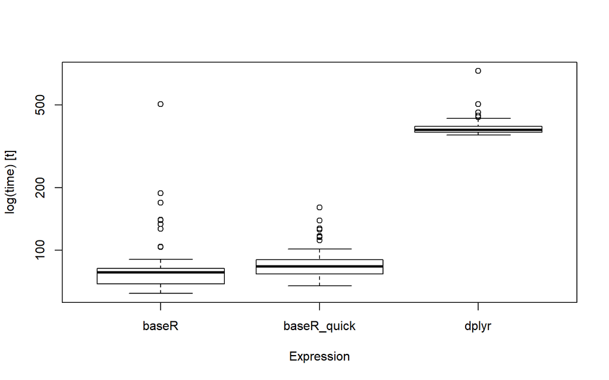

```r
prova <- mat_noti_noANPR[,"abbiategrasso"]

bench <- microbenchmark::microbenchmark(times = 100,
  baseR        = {prova[sort.list(prova, na.last = NA), drop = FALSE]},
  baseR_quick  = {prova[sort.list(prova, na.last = NA, method = "quick"), drop = FALSE]},
  dplyr        = {arrange(as.data.frame(prova))}
)
boxplot(bench)
```

Il metodo di sorting più veloce risulta essere quello base di R.

Si procede quindi alla stima per tutti i comuni noANPR:

```r
comuni_vicini <- vector("list")

for(j in 1:nrow(italy_geo_noANPR)) {
  distanze <- mat_noti_noANPR[,j]
  distanze <- distanze[sort.list(distanze)]

  vicini = character()
  i=1
  for(i in 1:length(distanze)) {
    if(distanze[[i]] < 10000) {vicini <- c(vicini, names(distanze)[i])}
    else {break}
    i=i+1
  }

  a <- italy_geo_noANPR[j,"comune"]
  comuni_vicini[[as.character(a)]] <- vicini
}

remove(distanze, i, j, a, vicini)
```

Modifica di altri comuni, a causa di cambiamenti nel corso degli anni:

```r
# Cadrezzate con Osmate
Cadrezzate_con_Osmate <- data.frame("cadrezzate con osmate",
                                    popolazione_comuni_italiani[1030, "Value"] +
                                      popolazione_comuni_italiani[4770, "Value"])
names(Cadrezzate_con_Osmate) <- c("Territorio", "Value")
popolazione_comuni_italiani <- rbind(popolazione_comuni_italiani, Cadrezzate_con_Osmate)

# Vermezzo con Zelo
Vermezzo_con_Zelo <- data.frame("vermezzo con zelo",
                                    popolazione_comuni_italiani[7627, 2] +
                                      popolazione_comuni_italiani[7922, 2])
names(Vermezzo_con_Zelo) <- c("Territorio", "Value")
popolazione_comuni_italiani <- rbind(popolazione_comuni_italiani, Vermezzo_con_Zelo)

# Gornate Olona
popolazione_comuni_italiani[popolazione_comuni_italiani == "gornate-olona"] <- "gornate olona"

# Puegnago del Garda
popolazione_comuni_italiani[popolazione_comuni_italiani == "puegnago sul garda"] <- "puegnago del garda"


remove(Cadrezzate_con_Osmate, Vermezzo_con_Zelo)
```

Aggiunta della popolazione dei comuni noANPR:

```r
comuni_noANPR <- inner_join(comuni_noANPR, popolazione_comuni_italiani, by = c("NOME_COMUNE" = "Territorio"))
names(comuni_noANPR) <- c("comune", "Value")
```

Stima dei decessi e della relativa incertezza per i comuni noANPR:

```r
lista_comuni <- names(comuni_vicini)
num_comuni <- length(lista_comuni)

stima <- rep.int(0,num_comuni)
incertezza <- stima

for(i in 1:num_comuni) {
  comune <- lista_comuni[i]
  vicini <- comuni_vicini[[as.character(comune)]]
  num_vicini <- length(vicini)

  if(num_vicini > 0) {
    for(j in 1:num_vicini) {
      pos <- which(eccesso_noti['NOME_COMUNE'] == vicini[j])
      stima[i] <- stima[i] + eccesso_noti[pos, 'INCR_RELATIVO']
      incertezza[i] <- incertezza[i] + eccesso_noti[pos, 'INCERTEZZA_REL']
    }

    stima[i] <- stima[i] / num_vicini
    incertezza[i] <- incertezza[i] / num_vicini

  } else {
    stima[i] = 0
    incertezza[i] = 0
  }
}

comuni_noANPR['decessi2020'] <- stima * comuni_noANPR['Value']
comuni_noANPR['incertezza'] <- incertezza * comuni_noANPR['Value']

remove(num_comuni, stima, comune, i, j, incertezza, lista_comuni, num_vicini, pos, vicini)
```

# Stima dei comuni ignoti

È stata poi ricavata la lista dei comuni ignoti (aventi cioè un incremento dei decessi inferiore al 20% o con dati non affidabili), sottraendo alla lista dei comuni ANPR quelli per cui i dati del 2020 erano disponibili:

```r
comuni_ignoti <- as.data.frame(setdiff(comuni_ANPR$Comune, comuni_noti2020$NOME_COMUNE))

comuni_ignoti <- inner_join(Lombardia, comuni_ignoti,
                            by = c("NOME_COMUNE" = "setdiff(comuni_ANPR$Comune, comuni_noti2020$NOME_COMUNE)"))
comuni_ignoti['NOME_COMUNE'] %>% group_by(NOME_COMUNE) %>% summarise() -> comuni_ignoti
```

È stata poi creata la matrice delle distanze tra i comuni ignoti (sulle colonne) e gli ANPR (sulle righe), dopo aver aggiunto i relativi dati di posizione.

```r
italy_geo_ANPR <- inner_join(italy_geo, comuni_ANPR['Comune'], by = c("comune" = "Comune"))[c(1:3)]

italy_geo_ignoti <- inner_join(italy_geo, comuni_ignoti, by = c("comune" = "NOME_COMUNE"))[c(1:3)]

myList1 <- setNames(split(italy_geo_ANPR[,c(2,3)], seq_len(nrow(italy_geo_ANPR))),
                    italy_geo_ANPR$comune)
myList2 <- setNames(split(italy_geo_ignoti[,c(2,3)], seq_len(nrow(italy_geo_ignoti))),
                    italy_geo_ignoti$comune)

mat_ignoti_ANPR <- outer(myList1, myList2, Vectorize(distHaversine))

remove(myList1, myList2)
```

Nel dataset ISTAT, l’assenza di dati per il 2020 corrisponde a comuni che presentano un incremento dei decessi inferiore al 20%, rispetto alla media degli anni precedenti, oppure a comuni i cui dati non sono stati comunicati, in quanto ritenuti inaffidabili. Per distinguere queste due categorie, si è deciso di tener conto dei dati dei comuni vicini. In particolare, si è ritenuto opportuno classificare come “comuni sotto al 20%” i comuni con la maggior parte dei vicini appartenenti ai comuni ignoti e come “comuni con dati non disponibili” quelli con la maggior parte dei vicini aventi dati noti.

Questo perché si è ipotizzato che:

- Se un comune ha una maggioranza di vicini con dati noti, è probabile che anch’esso abbia avuto un incremento di decessi superiore al 20%, ma che i suoi dati siano stati ritenuti inaffidabili.
- Se un comune ha in prevalenza vicini ignoti, è più probabile invece che quella zona sia stata poco colpita dal virus e che quindi ci sia stato un incremento di decessi inferiore al 20%.

```r
classificazione <- rep.int(0,nrow(italy_geo_ignoti))

lista_comuni_ignoti <- comuni_ignoti[['NOME_COMUNE']]

for(j in 1:nrow(italy_geo_ignoti)) {
  distanze <- mat_ignoti_ANPR[,j]
  distanze <- distanze[sort.list(distanze)]

  vicini = character()
  i=1
  for(i in 1:length(distanze)) {
    if(distanze[[i]] < 10000) {vicini <- c(vicini, names(distanze)[i])}
    else {break}
    i=i+1
  }


  a <- 0
  i <- 1
  if(length(vicini) > 0) {
    for(i in 1:length(vicini)) {
      if(vicini[i] %in% lista_comuni_ignoti) a <- a - 1
      else a <- a + 1
    }
  }


  # Se a è positivo, prevalgono i vicini noti e il comune è classificato come un comune che non ha
  # comunicato i dati.
  # Se a è negativo, come un comune sotto al 20%.

  if(a > 0) classificazione[j] <- "dati non disponibili"
  else classificazione[j] <- "sotto al 20%"
}


comuni_ignoti['CLASSIFICAZIONE'] <- classificazione

as.table(summary(as.factor(classificazione)))
```

```
## dati non disponibili         sotto al 20%
##                  146                  351
```

```r
remove(distanze, a, i, j, vicini, classificazione, lista_comuni_ignoti)
```

Dei 497 comuni ignoti, 351 sono stati classificati come comuni con un incremento inferiore al 20% e 146 come comuni con un incremento superiore ma dati inaffidabili.

Si è deciso quindi di trattare in modo differente le due categorie.

## Stima dei comuni “non disponibili”

Per i comuni classificati come “comuni con dati non disponibili”, è stato applicato lo stesso calcolo effettuato in precedenza: è stata quindi calcolata la media degli incrementi dei decessi (in percentuale sulla popolazione) nei comuni limitrofi.

```r
nondisp <- select(filter(comuni_ignoti, CLASSIFICAZIONE == 'dati non disponibili'), c(1))
italy_geo_nondisp <- inner_join(italy_geo, nondisp, by = c("comune" = "NOME_COMUNE"))[c(1:3)]
italy_geo_nondisp %>% group_by(comune) %>% summarise(lng = first(lng), lat = first(lat)) -> italy_geo_nondisp



myList1 <- setNames(split(italy_geo_noti[,c(2,3)], seq_len(nrow(italy_geo_noti))),
                    italy_geo_noti$comune)
myList2 <- setNames(split(italy_geo_nondisp[,c(2,3)], seq_len(nrow(italy_geo_nondisp))),
                    italy_geo_nondisp$comune)

mat_noti_nondisp <- outer(myList1, myList2, Vectorize(distHaversine))

remove(myList1, myList2)
```

```r
comuni_ignoti <- inner_join(comuni_ignoti, popolazione_comuni_italiani, by = c("NOME_COMUNE" = "Territorio"))
```

```r
lista_comuni_nondisp <- as.vector(comuni_ignoti[which(comuni_ignoti['CLASSIFICAZIONE'] == "dati non disponibili"),"NOME_COMUNE"])
lista_comuni_nondisp <- lista_comuni_nondisp[['NOME_COMUNE']]
num_comuni_nondisp <- sum(comuni_ignoti['CLASSIFICAZIONE'] == "dati non disponibili")



comuni_vicini2 <- vector("list")

for(j in 1:nrow(italy_geo_nondisp)) {
  distanze <- mat_noti_nondisp[,j]
  distanze <- distanze[sort.list(distanze)]

  vicini = character()
  i=1
  for(i in 1:length(distanze)) {
    if(distanze[[i]] < 10000) {vicini <- c(vicini, names(distanze)[i])}
    else {break}
    i=i+1
  }

  a <- italy_geo_nondisp[j,"comune"]
  comuni_vicini2[[as.character(a)]] <- vicini
}

remove(distanze, i, j, a, vicini)



stima <- rep.int(0,nrow(comuni_ignoti))
incertezza <- stima

for(i in 1:nrow(comuni_ignoti)) {
  comune <- comuni_ignoti[i,'NOME_COMUNE']
  if(comune %in% lista_comuni_nondisp) {

    vicini <- comuni_vicini2[[as.character(comune)]]
    num_vicini <- length(vicini)

    if(num_vicini > 0) {
      for(j in 1:num_vicini) {
        pos <- which(eccesso_noti['NOME_COMUNE'] == vicini[j])
        stima[i] <- stima[i] + eccesso_noti[pos, 'INCR_RELATIVO']
        incertezza[i] <- incertezza[i] + eccesso_noti[pos, 'INCERTEZZA_REL']
      }

      stima[i] <- stima[i] / num_vicini
      incertezza[i] <- incertezza[i] / num_vicini

    } else {
      stima[i] = 0
      incertezza[i] = 0
    }
  }
}

comuni_ignoti['decessi2020'] <- stima * comuni_ignoti['Value']
comuni_ignoti['incertezza2020'] <- incertezza * comuni_ignoti['Value']

remove(stima, comune, i, j, incertezza, num_vicini, pos, vicini, num_comuni_nondisp)
```

## Stima dei comuni sotto al 20%

Per i comuni classificati come “sotto al 20%”, si è scelto di utilizzare per il 2020 la media dei decessi avvenuti negli anni precedenti incrementata del 10% (scegliendo cioè un valore medio tra i due estremi 0% e 20%). Per dare una stima dell’incertezza di questo dato, si è ipotizzato che tale valore medio provenga da una distribuzione normale. In particolare, si ipotizza una distribuzione normale centrata su 10% e deviazione standard tale che l’intervallo di confidenza al 99% coincida con l’intervallo (0%,20%).

Stima dei comuni sotto al 20%, attribuendo una percentuale media del 10%:

```r
comuni_ignoti1519 <- select(filter(Lombardia, DATA_INIZIO_DIFF == 'Dati 2020 n.d.'), c(1:29))
comuni_ignoti1519 <- inner_join(comuni_ignoti1519, comuni_ANPR['Comune'], by = c("NOME_COMUNE" = "Comune"))
comuni_ignoti1519 <- comuni_ignoti1519 %>% gather(key = "SESSO_ANNO", value = "DECESSI", MASCHI_15:TOTALE_20)
comuni_ignoti1519 %>% separate(SESSO_ANNO, c("SESSO", "ANNO"), "_") -> comuni_ignoti1519
comuni_ignoti1519 <- select(filter(comuni_ignoti1519, SESSO != "TOTALE"), c(1:14))
comuni_ignoti1519 <- select(filter(comuni_ignoti1519, ANNO != "20"), c(1:14))
comuni_ignoti1519 %>% group_by(NOME_COMUNE, ANNO) %>% summarise(DECESSI = sum(DECESSI)) -> comuni_ignoti1519

comuni_ignoti1519 %>% group_by(NOME_COMUNE) %>% summarise(DECESSI_MEDI = mean(DECESSI),
                                                          INCERTEZZA = 1.96 * sd(DECESSI) / sqrt(5-1)) -> comuni_ignoti1519

comuni_ignoti["DECESSI_MEDI_1519"] <- comuni_ignoti1519["DECESSI_MEDI"]
comuni_ignoti["INCERTEZZA_1519"] <- comuni_ignoti1519["INCERTEZZA"]
```

```r
sigma <- 0.1 / 2.58

pos <- comuni_ignoti["CLASSIFICAZIONE"] == "sotto al 20%"

comuni_ignoti[pos, "decessi2020"] <- comuni_ignoti[pos, "DECESSI_MEDI_1519"] * 1.1
comuni_ignoti[pos, "incertezza2020"] <- comuni_ignoti[pos, "INCERTEZZA_1519"] * sigma

remove(pos)
```

# Stima dei decessi totali in Lombardia

Avendo quindi stimato l’incremento di decessi per ogni tipologia di comune, si procede alla stima dei decessi totali in Lombardia:

```r
Incremento2020 <- sum(eccesso_noti$INCREMENTO) + sum(comuni_ignoti$decessi2020) + sum(comuni_noANPR$decessi2020)
Incertezza2020 <- sum(eccesso_noti$INCERTEZZA) + sum(comuni_ignoti$incertezza2020) + sum(comuni_noANPR$incertezza)

Decessi1519 <- Lombardia
Decessi1519 <- select(filter(Decessi1519, (MESE <3)), c(1:29))
Decessi1519 <- Decessi1519 %>% gather(key = "SESSO_ANNO", value = "DECESSI", MASCHI_15:TOTALE_20)
Decessi1519 %>% separate(SESSO_ANNO, c("SESSO", "ANNO"), "_") -> Decessi1519
Decessi1519 <- select(filter(Decessi1519, SESSO != "TOTALE"), c(1:14))
Decessi1519 <- select(filter(Decessi1519, ANNO != "20"), c(5,13,14))
Decessi1519 %>% group_by(NOME_COMUNE, ANNO) %>% summarise(DECESSI = sum(DECESSI)) -> Decessi1519

Decessi1519 %>% group_by(NOME_COMUNE) %>% summarise(DECESSI_MEDI = mean(DECESSI), INCERTEZZA = 1.96 * sd(DECESSI) / sqrt(5-1)) -> Decessi1519

Totale_Decessi_1519=sum(Decessi1519$DECESSI_MEDI)

Totale_Incertezza_1519=sum(Decessi1519$INCERTEZZA)

Totale_Decessi_2020=Incremento2020+Totale_Decessi_1519
Totale_Incertezza_2020=Incertezza2020+Totale_Incertezza_1519
```

Confronto tra la media 2015-19 e la stima 2020:

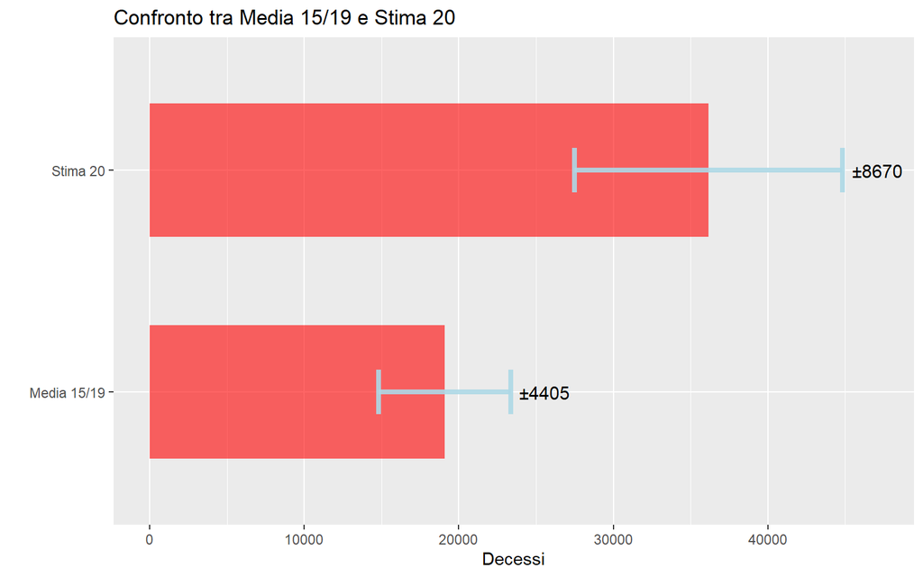

Risulta quindi evidente un effettivo incremento dei decessi nel 2020 rispetto ai cinque anni precedenti, anche al netto delle incertezze.

Infine, si procede al calcolo dei decessi ufficiali dal dataset ISTAT aggiornato, pubblicato il 5 maggio:

```r
dataset_aggiornato <- select(filter(dataset_aggiornato, NOME_REGIONE == "Lombardia"), c(5,7,8,9))

dataset_aggiornato["01/01-31/03"] <- dataset_aggiornato[2] + dataset_aggiornato[3] + dataset_aggiornato[4]

Decessi_ufficiali_2020 <- sum(dataset_aggiornato$`01/01-31/03`)
```

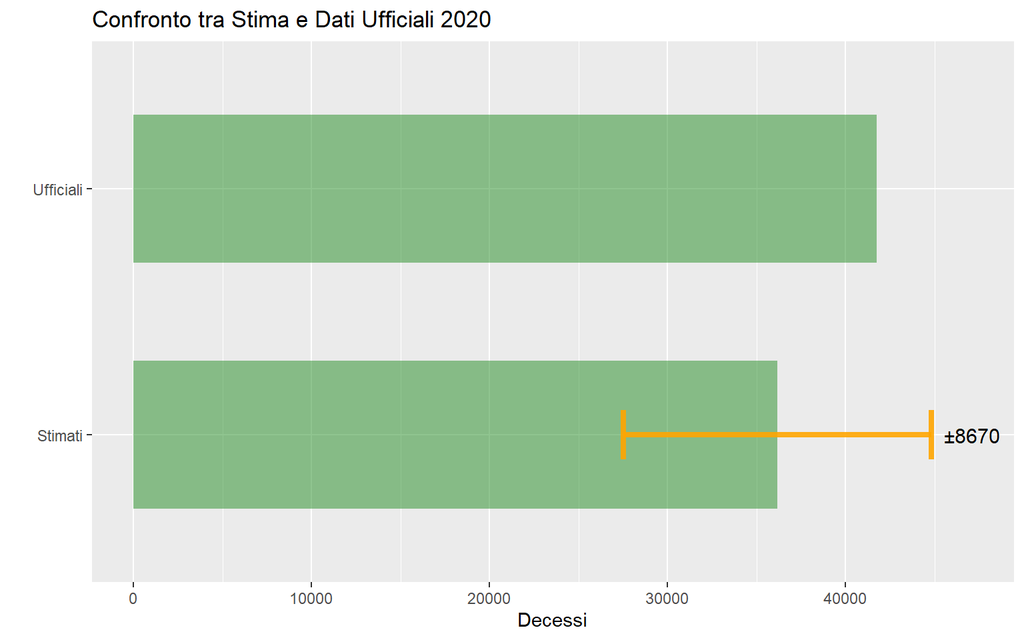

Pertanto, dal confronto si conclude che la stima ottenuta, con la relativa incertezza, risulta totalmente compatibile con i dati ufficiali.